# [Chapter 11] Predicting online shopping purchase intent using using logistic regression

[DSLC stages]: Analysis

In this document, you will find the PCS workflow and code for fitting logistic regression to the online shopping data.

The following code sets up the libraries and creates cleaned and pre-processed training, validation and test data that we will use in this document.

```r
library(patchwork)
library(lubridate)
library(scales)
library(yardstick)
library(fastDummies)
library(tidyverse)
library(janitor)
# apply the cleaning and pre-processing functions
source("functions/prepareShoppingData.R")
# list all objects (and custom functions) that exist in our environment
ls()
```

```
 [1] "browser_levels"                      "operating_systems_levels"
 [3] "preprocessShoppingData"              "shopping_orig"
 [5] "shopping_test"                       "shopping_test_preprocessed"
 [7] "shopping_train"                      "shopping_train_preprocessed"
 [9] "shopping_train_preprocessed_nodummy" "shopping_val"
[11] "shopping_val_preprocessed"           "shopping_val_preprocessed_nodummy"
[13] "traffic_type_levels"
```

```r
# create a LS fit for use later
ls_all <- lm(parse_number(as.character(purchase)) ~ .,
             shopping_train_preprocessed)
```

Note that the `glm()` function expects that the first level of the response factor is the “failure” (no purchase) level.

## 1 LS and Logistic regression for a small sample of 20 training points

```r
# create a version of the training dataset with just the 20 training sessions
shopping_train_sample <- shopping_train_preprocessed |>
  # create a temporary id column
  mutate(id = 1:n()) |>
  # filter the the same sessions that were used in the book chapter
  filter(id %in% c(753, 6492, 6801, 1877,
                   3298, 3635,  603, 3632, 4258, 4783, 2758, 4615, 7313,
                   3012, 2109, 7138, 5740, 270, 2899,  425)) |>
  select(-id)
```

The code below fits a simple one-predictor LS fit using this sample of 20 training sessions:

```r
ls_example <- lm(parse_number(as.character(purchase)) ~ product_related_duration,
                 shopping_train_sample)
ls_example
```

```
Call:
lm(formula = parse_number(as.character(purchase)) ~ product_related_duration,
    data = shopping_train_sample)

Coefficients:
             (Intercept)  product_related_duration
                -0.19407                   0.04761
```

To use this fit to generate predictions, we can use the `predict()` function. For example, to predict the purchase response of a session that spent 20 minutes on product-related pages:

```r
predict(ls_example, tibble(product_related_duration = 20))
```

```
        1
0.7581521
```

Note that this is neither 0 nor is it 1. What does it mean to have a predicted purchase response of 0.76? Since it is above 0.5[^1], we could round it up to 1 and predict that the response of such a session is “purchase” (i.e., equal to 1).

The corresponding logistic regression fit can be computed using `glm()` with the `family = "binomial"` argument:

```r
logistic_example <- glm(factor(purchase, levels = c(0, 1)) ~ product_related_duration,
                        shopping_train_sample,
                        family = "binomial")
logistic_example
```

```
Call:  glm(formula = factor(purchase, levels = c(0, 1)) ~ product_related_duration,
    family = "binomial", data = shopping_train_sample)

Coefficients:
             (Intercept)  product_related_duration
                 -8.6391                    0.6128

Degrees of Freedom: 19 Total (i.e. Null);  18 Residual
Null Deviance:      20.02
Residual Deviance: 9.283    AIC: 13.28
```

```r
predict(logistic_example, tibble(product_related_duration = 20),
        type = "response")
```

```
        1
0.9738247
```

## 2 Fitting logistic regression to the full training dataset

Next, we can move beyond this sample of just 20 training data points and compute a logistic regression fit for the entire training dataset:

```r
lr_all <- glm(factor(purchase, levels = c(0, 1)) ~ .,
              shopping_train_preprocessed,
              family = "binomial")
lr_all
```

```
Call:  glm(formula = factor(purchase, levels = c(0, 1)) ~ ., family = "binomial",
    data = shopping_train_preprocessed)

Coefficients:
             (Intercept)            administrative   administrative_duration
              -1.742e+00                 1.310e-02                -4.404e-03
           informational    informational_duration           product_related
              -5.166e-04                 1.715e-02                 1.775e-03
product_related_duration              bounce_rates                exit_rates
               3.005e-03                -1.561e-01                -1.486e+01
             page_values               special_day                   weekend
               8.156e-02                -3.596e-01                 6.908e-02
          return_visitor                 month_Dec                 month_Feb
              -2.007e-01                -8.377e-01                -2.368e+00
               month_Jul                month_June                 month_Mar
               2.088e-01                -7.394e-01                -6.461e-01
               month_May                 month_Nov                 month_Oct
              -6.190e-01                 4.117e-01                -1.547e-01
               month_Sep       operating_systems_2       operating_systems_3
              -3.492e-02                 1.925e-01                 5.380e-02
     operating_systems_4       operating_systems_8   operating_systems_other
              -2.382e-01                 1.006e-02                -2.391e-01
               browser_2                 browser_3                 browser_4
              -1.892e-01                -9.920e-01                -3.419e-02
               browser_5                 browser_6                 browser_8
              -8.120e-02                -6.060e-01                -3.698e-01
              browser_10             browser_other                  region_2
               1.613e-02                -1.859e-01                 2.121e-01
                region_3                  region_4                  region_5
               1.083e-01                -9.811e-02                -3.474e-01
                region_6                  region_7                  region_8
              -1.870e-02                 9.657e-02                -2.035e-01
                region_9            traffic_type_2            traffic_type_3
              -3.466e-01                 2.252e-01                -3.253e-01
          traffic_type_4            traffic_type_5            traffic_type_6
              -5.180e-02                 7.855e-02                -1.195e-01
          traffic_type_8           traffic_type_10           traffic_type_11
               7.890e-01                 3.975e-01                 4.371e-01
         traffic_type_13           traffic_type_20        traffic_type_other
              -4.771e-01                 6.159e-01                 1.293e-01

Degrees of Freedom: 7371 Total (i.e. Null);  7318 Residual
Null Deviance:      6514
Residual Deviance: 4344     AIC: 4452
```

### 2.1 Comparing the coefficients using bootstrap standardization

Just as was the case for the LS algorithm, the coefficients of each predictive feature are not comparable unless the features have been pre-standardized (i.e., prior to fitting the logistic regression model) or the coefficients have been standardized, e.g., by using the bootstrap to estimate the standard deviation of each coefficient, and then dividing each coefficient by these estimated standard deviations.

The code below demonstrates the latter bootstrapping approach to computing comparable coefficients.

First, we will create 1000 bootstrapped (sampled with replacement) versions of the training dataset, and we will compute a logistic regression fit to each bootstrapped training data sample.

```r
# (this code will take a moment to run)
set.seed(27398)
boot_coefs <- map_df(1:1000, function(i) {
  # print out which iteration we are up to
  print(i)
  # create a bootstrapped sample
  shopping_boot <- shopping_train_preprocessed |>
    sample_frac(1, replace = TRUE)
  # compute a logistic regression fit
  lr_all_boot <- glm(factor(purchase, levels = c(0, 1)) ~ .,
                     shopping_boot,
                     family = "binomial")
  # return the results in a data frame
  return(enframe(lr_all_boot$coefficients,
                 name = "variable",
                 value = "coefficient"))
  # create a "boot" identifier
}, .id = "boot")
```

```r
# look at the object we just created
boot_coefs
```

```
# A tibble: 54,000 × 3
   boot  variable                 coefficient
   <chr> <chr>                          <dbl>
 1 1     (Intercept)                -2.01
 2 1     administrative              0.0227
 3 1     administrative_duration    -0.00407
 4 1     informational               0.0147
 5 1     informational_duration     -0.00739
 6 1     product_related             0.000646
 7 1     product_related_duration    0.00548
 8 1     bounce_rates                0.869
 9 1     exit_rates                -13.5
10 1     page_values                 0.0880
# ℹ 53,990 more rows
```

Having computed 1000 bootstrapped coefficient values, we can compute their standard deviation, and use this value to standardize the original coefficient values

```r
# standardize the coefficients
coefs_std <- boot_coefs |>
  # for each variable
  group_by(variable) |>
  # compute the standard deviation of the bootstrapped coefficient values
  summarise(boot_sd = sd(coefficient)) |>
  ungroup() |>
  # add a column with the original coefficient values (joined by variable)
  left_join(enframe(lr_all$coefficients,
                    name = "variable",
                    value = "coefficient"),
            by = "variable") |>
  # compute the standardized coefficients by dividing by the bootstrapped sd
  mutate(standardized_coefficient = coefficient / boot_sd) |>
  # arrange in descending order of (abs value) standardized coefficient
  arrange(desc(abs(standardized_coefficient))) |>
  # remove the intercept
  filter(variable != "(Intercept)") |>
  select(variable, coefficient, boot_sd, standardized_coefficient)

print(coefs_std, width = Inf)
```

```
# A tibble: 53 × 4
   variable        coefficient boot_sd standardized_coefficient
   <chr>                 <dbl>   <dbl>                    <dbl>
 1 page_values          0.0816 0.00604                    13.5
 2 exit_rates         -14.9    2.73                       -5.45
 3 traffic_type_8       0.789  0.226                       3.49
 4 month_Dec           -0.838  0.256                      -3.28
 5 month_Mar           -0.646  0.234                      -2.76
 6 month_May           -0.619  0.226                      -2.74
 7 traffic_type_10      0.398  0.198                       2.00
 8 traffic_type_3      -0.325  0.165                      -1.97
 9 month_Nov            0.412  0.224                       1.84
10 traffic_type_2       0.225  0.123                       1.83
# ℹ 43 more rows
```

The `page_values` feature has the largest standardized coefficient *by far*, indicating that it is the variable that is most predictive of the purchase response.

## 3 Evaluating binary predictions for a sample of 20 validation points

First, let’s start by evaluating our predictions using just a random sample of 20 validation set sessions.

Let’s create the same 20-session sample that was used in the book for evaluation.

```r
sample_index <- c(961, 1315, 408, 1678, 1810,
                  1566, 2036, 1005, 2198, 685,
                  1680, 1347, 2265, 286, 1393,
                  2267, 2247, 1576, 217, 420)
shopping_val_sample <- shopping_val_preprocessed[sample_index, ]
```

First, let’s print out the observed and predicted (using LS and logistic regression fit to the full training set) purchase response for these 20 validation sessions.

```r
pred_val_sample <- shopping_val_sample |>
  transmute(purchase = purchase,
            ls_predict = predict(ls_all, shopping_val_sample),
            ls_predict_binary = factor(as.numeric(ls_predict > 0.5), levels = c(1, 0)),
            lr_predict = predict(lr_all, shopping_val_sample,
                                 type = "response"),
            lr_predict_binary = factor(as.numeric(lr_predict > 0.5), levels = c(1, 0)))
pred_val_sample
```

```
# A tibble: 20 × 5
   purchase ls_predict ls_predict_binary lr_predict lr_predict_binary
   <fct>         <dbl> <fct>                  <dbl> <fct>
 1 1            0.335  0                     0.355  0
 2 1            0.328  0                     0.420  0
 3 1            0.618  1                     0.893  1
 4 1            0.428  0                     0.664  1
 5 1            0.417  0                     0.594  1
 6 0            0.0778 0                     0.0425 0
 7 0            0.348  0                     0.398  0
 8 0            0.0565 0                     0.0433 0
 9 0            0.0545 0                     0.0390 0
10 0            0.0847 0                     0.0617 0
11 0            0.0618 0                     0.0432 0
12 0            0.192  0                     0.184  0
13 0            0.235  0                     0.221  0
14 0            0.0879 0                     0.0650 0
15 0            0.127  0                     0.100  0
16 0            0.433  0                     0.583  1
17 0            0.375  0                     0.450  0
18 0            0.318  0                     0.363  0
19 0            0.505  1                     0.764  1
20 0            0.393  0                     0.539  1
```

### 3.1 The confusion matrix

The confusion matrix for the LS (binary) fit, where the binary predictions are based (for now) on a threshold of 0.5, is

```r
conf_ls <- table(pred_val_sample$purchase, pred_val_sample$ls_predict_binary)
conf_ls
```

```
     1  0
  1  1  4
  0  1 14
```

and for the logistic regression fit, the confusion matrix (again, for now, based on a threshold of 0.5) is:

```r
conf_lr <- table(pred_val_sample$purchase, pred_val_sample$lr_predict_binary)
conf_lr
```

```
     1  0
  1  3  2
  0  3 12
```

### 3.2 Prediction accuracy

There are several ways that you can compute the prediction accuracy, such as from the confusion matrix, by adding up the diagonal entries and dividing by the total:

```r
(conf_ls[1, 1] + conf_ls[2, 2]) / sum(conf_ls)
```

```
[1] 0.75
```

```r
(conf_lr[1, 1] + conf_lr[2, 2]) / sum(conf_lr)
```

```
[1] 0.75
```

or using the `accuracy()` function (if using columns of a data frame, alternatively if providing vectors, you can use the `accuracy_vec()` function) from the “yardstick” library

```r
pred_val_sample |>
  accuracy(truth = purchase,
           estimate = ls_predict_binary)
```

```
# A tibble: 1 × 3
  .metric  .estimator .estimate
  <chr>    <chr>          <dbl>
1 accuracy binary          0.75
```

```r
pred_val_sample |>
  accuracy(truth = purchase,
           estimate = lr_predict_binary)
```

```
# A tibble: 1 × 3
  .metric  .estimator .estimate
  <chr>    <chr>          <dbl>
1 accuracy binary          0.75
```

### 3.3 True positiveand true negative rate

Similarly, the true positive rate can be computed from the confusion matrix:

```r
conf_ls[1, 1] / sum(conf_ls[1, ])
```

```
[1] 0.2
```

```r
conf_lr[1, 1] / sum(conf_ls[1, ])
```

```
[1] 0.6
```

or using the `sens()` or `sens_vec()` sensitivity functions from the yardstick package

```r
pred_val_sample |>
  sens(truth = purchase,
       estimate = ls_predict_binary)
```

```
# A tibble: 1 × 3
  .metric .estimator .estimate
  <chr>   <chr>          <dbl>
1 sens    binary           0.2
```

```r
pred_val_sample |>
  sens(truth = purchase,
       estimate = lr_predict_binary)
```

```
# A tibble: 1 × 3
  .metric .estimator .estimate
  <chr>   <chr>          <dbl>
1 sens    binary           0.6
```

and the equivalent computations can be performed for the true negative rate (specificity)

Similarly, the true negative rate can be computed from the confusion matrix:

```r
conf_ls[2, 2] / sum(conf_ls[2, ])
```

```
[1] 0.9333333
```

```r
conf_lr[2, 2] / sum(conf_ls[2, ])
```

```
[1] 0.8
```

or using the `specificity()` or `spec_vec()` sensitivity functions from the yardstick package

```r
pred_val_sample |>
  specificity(truth = purchase,
              estimate = ls_predict_binary)
```

```
# A tibble: 1 × 3
  .metric     .estimator .estimate
  <chr>       <chr>          <dbl>
1 specificity binary         0.933
```

```r
pred_val_sample |>
  specificity(truth = purchase,
              estimate = lr_predict_binary)
```

```
# A tibble: 1 × 3
  .metric     .estimator .estimate
  <chr>       <chr>          <dbl>
1 specificity binary           0.8
```

### 3.4 Predicted probability densities

We can also plot the distribution of the predicted probabilities using `geom_density()`

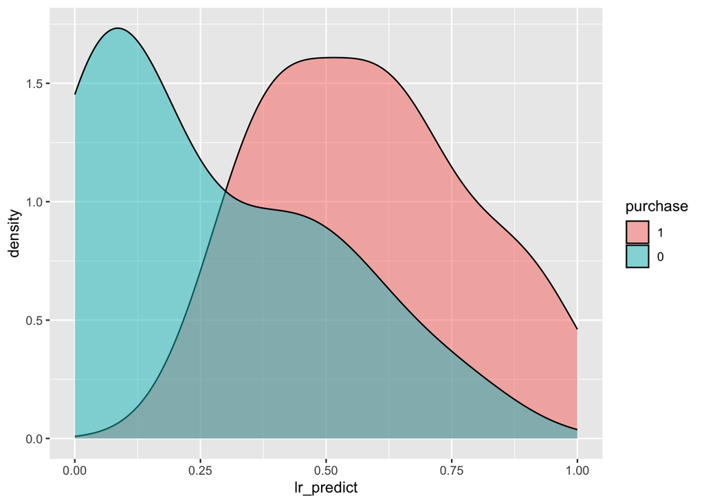

```r
pred_val_sample |>
  ggplot() +
  geom_density(aes(x = lr_predict, fill = purchase),
               alpha = 0.5) +
  scale_x_continuous(limits = c(0, 1))
```

Note, however, that using densities for so few samples is a bit misleading (there are only 5 data points in the “1” purchase class). A histogram would technically be more appropriate:

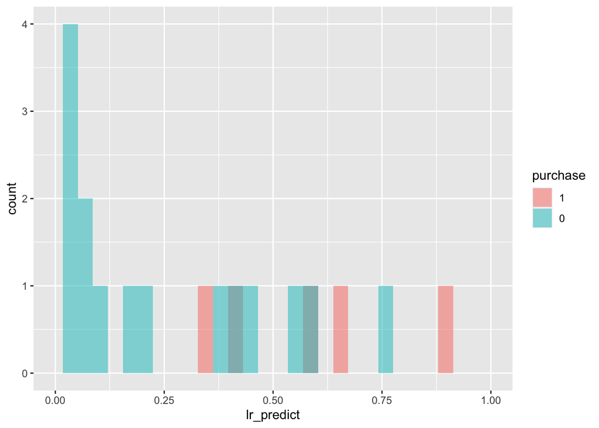

```r
pred_val_sample |>
  ggplot() +
  geom_histogram(aes(x = lr_predict, fill = purchase),
                 position = "identity",
                 alpha = 0.5) +
  scale_x_continuous(limits = c(0, 1))
```

### 3.5 ROC curves

Computing ROC curves is easy with the “yardstick” `roc_curve()` function. Let’s plot an ROC curve for the LS and logistic regression predictions on the same plot

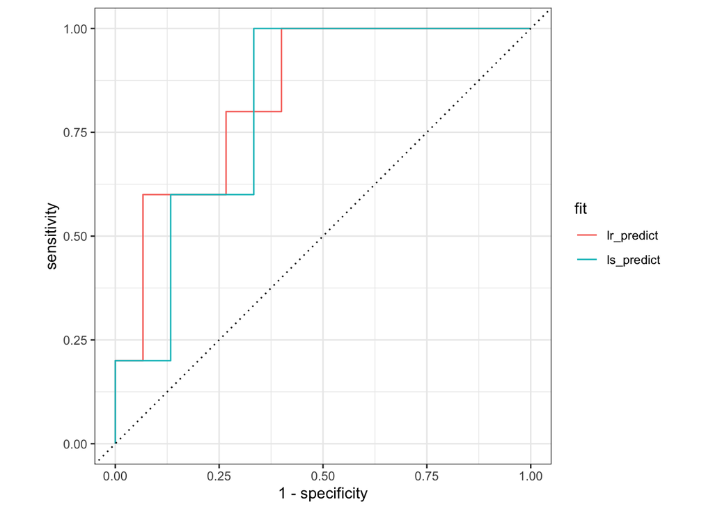

```r
pred_val_sample |>
  select(purchase, ls_predict, lr_predict) |>
  pivot_longer(c("ls_predict", "lr_predict"),
               names_to = "fit", values_to = "pred") |>
  group_by(fit) |>
  roc_curve(purchase, pred) |>
  autoplot()
```

The AUC of each plot can be computed using the `roc_auc()` or `roc_auc_vec()` function (depending on usage context – the `_vec()` version must be used if it is *within* a dplyr function like `mutate()` or `summarise()`).

```r
pred_val_sample |>
  select(purchase, ls_predict, lr_predict) |>
  pivot_longer(c("ls_predict", "lr_predict"),
               names_to = "fit", values_to = "pred") |>
  group_by(fit) |>
  summarise(auc = roc_auc_vec(truth = purchase, estimate = pred))
```

```
# A tibble: 2 × 2
  fit          auc
  <chr>      <dbl>
1 lr_predict 0.84
2 ls_predict 0.813
```

## 4 PCS evaluations

### 4.1 Predictability (evaluating binary predictions for the full validation set)

Our predictability evaluation involves much the same computations as the previous section, but this time evaluated using the *entire* validation set, rather than just the sample of 20 validation set data points.

Note that we will use a threshold of 0.161 (the proportion of training sessions that ended with a purchase, as computed in the code below) to convert the continuous response predictions (probabilities, in the case of logistic regression) to binary predictions.

```r
# compute the proportion of training observations in each class
shopping_train_preprocessed |>
  count(purchase) |>
  mutate(prop = n / sum(n))
```

```
# A tibble: 2 × 3
  purchase     n  prop
  <fct>    <int> <dbl>
1 1         1189 0.161
2 0         6183 0.839
```

Let’s evaluate the LS and logistic regression fits on the entire validation set. First, we need to compute the predictions for the validation set.

```r
pred_val <- tibble(purchase = shopping_val_preprocessed$purchase,
                   ls_predict = predict(ls_all, shopping_val_preprocessed),
                   lr_predict = predict(lr_all, shopping_val_preprocessed,
                                        type = "response"))
print(pred_val, width = Inf)
```

```
# A tibble: 2,456 × 3
   purchase ls_predict lr_predict
   <fct>         <dbl>      <dbl>
 1 0          -0.0287     0.00265
 2 0           0.00491    0.00540
 3 0           0.0602     0.0125
 4 0          -0.0605     0.00221
 5 0           0.0865     0.0138
 6 0          -0.0338     0.00383
 7 0          -0.0507     0.00286
 8 0           0.0234     0.00845
 9 0           0.0521     0.00835
10 0           0.0143     0.00739
# ℹ 2,446 more rows
```

Then we can compute many of the performance metrics at once:

```r
pred_val |>
  pivot_longer(c("ls_predict", "lr_predict"),
               names_to = "fit", values_to = "pred") |>
  mutate(pred_binary = factor(as.numeric(pred > 0.161),
                              levels = c(1, 0))) |>
  group_by(fit) |>
  summarise(accuracy = accuracy_vec(truth = purchase,
                                    estimate = pred_binary),
            tp_rate = sens_vec(truth = purchase,
                               estimate = pred_binary),
            tn_rate = spec_vec(truth = purchase,
                               estimate = pred_binary),
            auc = roc_auc_vec(truth = purchase,
                              estimate = pred))
```

```
# A tibble: 2 × 5
  fit        accuracy tp_rate tn_rate   auc
  <chr>         <dbl>   <dbl>   <dbl> <dbl>
1 lr_predict    0.821   0.793   0.826 0.898
2 ls_predict    0.770   0.887   0.750 0.905
```

And we can plot ROC curves:

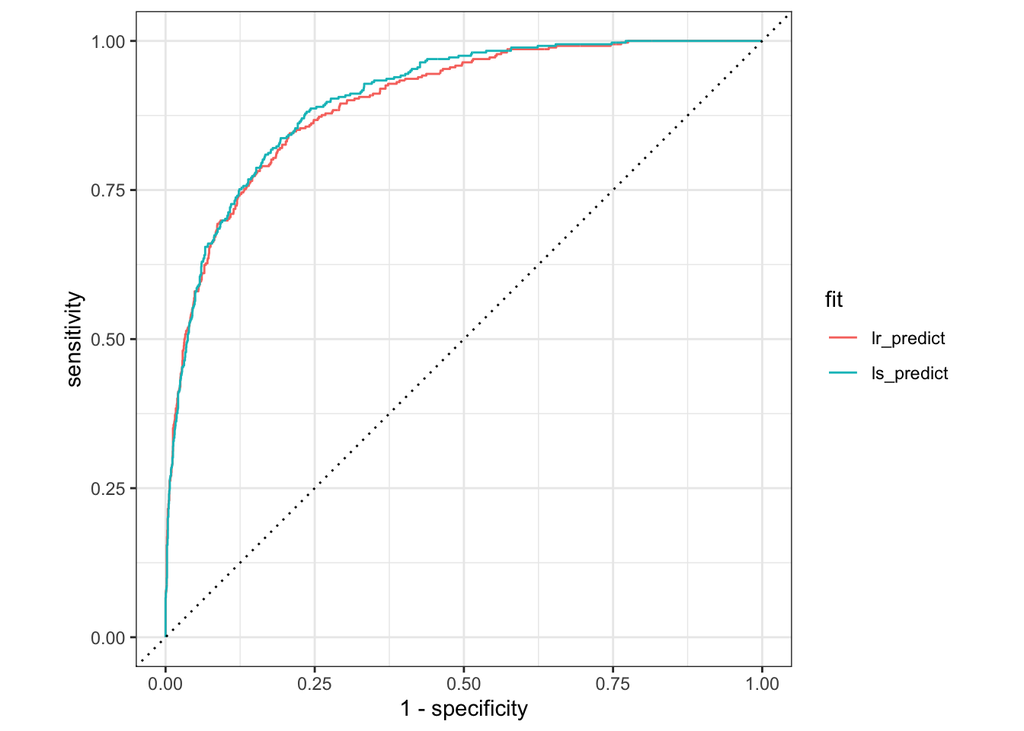

```r
pred_val |>
  select(purchase, ls_predict, lr_predict) |>
  pivot_longer(c("ls_predict", "lr_predict"),
               names_to = "fit", values_to = "pred") |>
  group_by(fit) |>
  roc_curve(purchase, pred) |>
  autoplot()
```

As well as density plots for both LS and logistic regression:

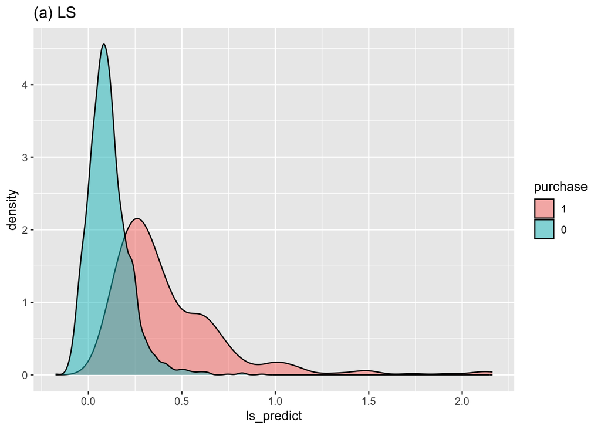

```r
pred_val |>
  ggplot() +
  geom_density(aes(x = ls_predict, fill = purchase), alpha = 0.5) +
  ggtitle("(a) LS")
```

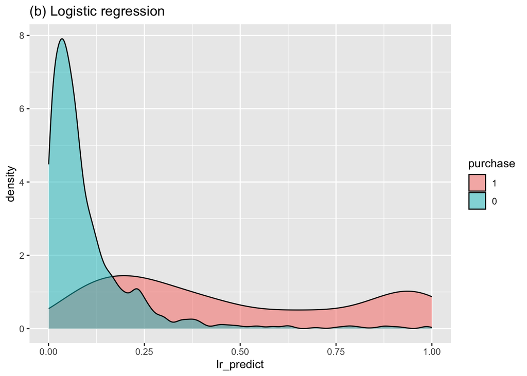

```r
pred_val |>
  ggplot() +
  geom_density(aes(x = lr_predict, fill = purchase), alpha = 0.5) +
  ggtitle("(b) Logistic regression")
```

### 4.2 Stability to data perturbations

To investigate the stability of each algorithm to data perturbations (specifically, bootstrap samples), we will first create 100 perturbed versions of the training dataset and store them in a tibble as a list column:

```r
set.seed(37698)
shopping_data_perturbed <- tibble(iter = 1:100) %>%
  rowwise() %>%
  # for each row, create a bootstrap sampled version of the training data
  mutate(data_train_preprocessed_perturbed = list(sample_frac(shopping_train_preprocessed, 1, replace = TRUE))) %>%
  ungroup()

shopping_data_perturbed
```

```
# A tibble: 100 × 2
    iter data_train_preprocessed_perturbed
   <int> <list>
 1     1 <tibble [7,372 × 54]>
 2     2 <tibble [7,372 × 54]>
 3     3 <tibble [7,372 × 54]>
 4     4 <tibble [7,372 × 54]>
 5     5 <tibble [7,372 × 54]>
 6     6 <tibble [7,372 × 54]>
 7     7 <tibble [7,372 × 54]>
 8     8 <tibble [7,372 × 54]>
 9     9 <tibble [7,372 × 54]>
10    10 <tibble [7,372 × 54]>
# ℹ 90 more rows
```

Then we can fit a LS and logistic regression fit to each perturbed dataset (and store these in list columns too). For each LS and logistic regression fit, we can then compute the validation set predictions and compute the relevant performance measures.

First, we will do this for the LS fits:

```r
shopping_data_perturbed_ls <- shopping_data_perturbed |>
  rowwise() |>
  # fit a LS for each perturbed training dataset
  mutate(ls = list(lm(parse_number(as.character(purchase)) ~ .,
                      data_train_preprocessed_perturbed))) |>
  # create a list column of just the observed response vector
  mutate(true = list(factor(shopping_val_preprocessed$purchase,
                            levels = c(1, 0)))) |>
  # compute a validation set prediction for each perturbed LS fit
  mutate(pred = list(predict(ls, shopping_val_preprocessed))) |>
  # compute the performance metrics for each fit
  mutate(auc = roc_auc_vec(true, pred),
         tp_rate = sens_vec(true, factor(as.numeric(pred > 0.161), levels = c(1, 0))),
         tn_rate = spec_vec(true, factor(as.numeric(pred > 0.161), levels = c(1, 0))),
         accuracy = accuracy_vec(true, factor(as.numeric(pred > 0.161), levels = c(1, 0))),
         .after = "pred") %>%
  ungroup()
# Look at the object we created
print(shopping_data_perturbed_ls, width = Inf)
```

```
# A tibble: 100 × 9
    iter data_train_preprocessed_perturbed ls     true          pred
   <int> <list>                            <list> <list>        <list>
 1     1 <tibble [7,372 × 54]>             <lm>   <fct [2,456]> <dbl [2,456]>
 2     2 <tibble [7,372 × 54]>             <lm>   <fct [2,456]> <dbl [2,456]>
 3     3 <tibble [7,372 × 54]>             <lm>   <fct [2,456]> <dbl [2,456]>
 4     4 <tibble [7,372 × 54]>             <lm>   <fct [2,456]> <dbl [2,456]>
 5     5 <tibble [7,372 × 54]>             <lm>   <fct [2,456]> <dbl [2,456]>
 6     6 <tibble [7,372 × 54]>             <lm>   <fct [2,456]> <dbl [2,456]>
 7     7 <tibble [7,372 × 54]>             <lm>   <fct [2,456]> <dbl [2,456]>
 8     8 <tibble [7,372 × 54]>             <lm>   <fct [2,456]> <dbl [2,456]>
 9     9 <tibble [7,372 × 54]>             <lm>   <fct [2,456]> <dbl [2,456]>
10    10 <tibble [7,372 × 54]>             <lm>   <fct [2,456]> <dbl [2,456]>
     auc tp_rate tn_rate accuracy
   <dbl>   <dbl>   <dbl>    <dbl>
 1 0.903   0.876   0.752    0.770
 2 0.900   0.876   0.756    0.774
 3 0.908   0.873   0.746    0.765
 4 0.899   0.862   0.761    0.776
 5 0.900   0.881   0.734    0.755
 6 0.901   0.862   0.751    0.768
 7 0.893   0.867   0.722    0.743
 8 0.902   0.884   0.753    0.772
 9 0.901   0.881   0.748    0.768
10 0.904   0.898   0.731    0.756
# ℹ 90 more rows
```

And then for the logistic regression fits:

```r
shopping_data_perturbed_lr <- shopping_data_perturbed |>
  rowwise() |>
  # fit a logistic regression for each perturbed training dataset
  mutate(lr = list(glm(factor(purchase, levels = c(0, 1)) ~ .,
                       data_train_preprocessed_perturbed,
                       family = "binomial"))) |>
  # create a list column of just the observed response vector
  mutate(true = list(factor(shopping_val_preprocessed$purchase,
                            levels = c(1, 0)))) |>
  # compute a validation set prediction for each perturbed LS fit
  mutate(pred = list(predict(lr, shopping_val_preprocessed,
                             type = "response"))) |>
  # compute the performance metrics for each fit
  mutate(auc = roc_auc_vec(true, pred),
         tp_rate = sens_vec(true, factor(as.numeric(pred > 0.161), levels = c(1, 0))),
         tn_rate = spec_vec(true, factor(as.numeric(pred > 0.161), levels = c(1, 0))),
         accuracy = accuracy_vec(true, factor(as.numeric(pred > 0.161), levels = c(1, 0))),
         .after = "pred") %>%
  ungroup()
# Look at the object we created
print(shopping_data_perturbed_lr, width = Inf)
```

```
# A tibble: 100 × 9
    iter data_train_preprocessed_perturbed lr     true          pred
   <int> <list>                            <list> <list>        <list>
 1     1 <tibble [7,372 × 54]>             <glm>  <fct [2,456]> <dbl [2,456]>
 2     2 <tibble [7,372 × 54]>             <glm>  <fct [2,456]> <dbl [2,456]>
 3     3 <tibble [7,372 × 54]>             <glm>  <fct [2,456]> <dbl [2,456]>
 4     4 <tibble [7,372 × 54]>             <glm>  <fct [2,456]> <dbl [2,456]>
 5     5 <tibble [7,372 × 54]>             <glm>  <fct [2,456]> <dbl [2,456]>
 6     6 <tibble [7,372 × 54]>             <glm>  <fct [2,456]> <dbl [2,456]>
 7     7 <tibble [7,372 × 54]>             <glm>  <fct [2,456]> <dbl [2,456]>
 8     8 <tibble [7,372 × 54]>             <glm>  <fct [2,456]> <dbl [2,456]>
 9     9 <tibble [7,372 × 54]>             <glm>  <fct [2,456]> <dbl [2,456]>
10    10 <tibble [7,372 × 54]>             <glm>  <fct [2,456]> <dbl [2,456]>
     auc tp_rate tn_rate accuracy
   <dbl>   <dbl>   <dbl>    <dbl>
 1 0.892   0.809   0.820    0.819
 2 0.897   0.812   0.832    0.829
 3 0.898   0.812   0.824    0.822
 4 0.891   0.796   0.830    0.825
 5 0.895   0.807   0.821    0.819
 6 0.890   0.782   0.832    0.825
 7 0.888   0.796   0.812    0.810
 8 0.895   0.809   0.823    0.821
 9 0.894   0.807   0.823    0.821
10 0.896   0.809   0.806    0.807
# ℹ 90 more rows
```

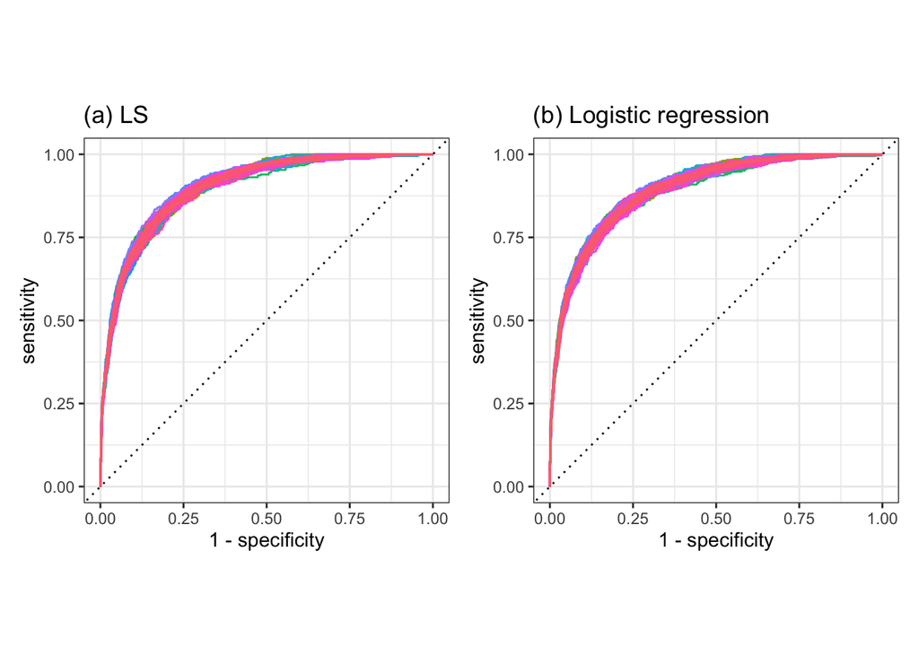

```r
gg_roc_ls_stab_data <- shopping_data_perturbed_ls %>%
  # select just the relevant columns
  select(iter, true, pred) %>%
  # unnest the predictions and true purchase response from the list columns
  unnest(c(iter, true, pred)) %>%
  # compute the ROC curve for each perturbed set of predictions
  group_by(iter) %>%
  roc_curve(true, pred) %>%
  autoplot() +
  theme(legend.position = "none") +
  ggtitle("(a) LS")

gg_roc_lr_stab_data <- shopping_data_perturbed_lr %>%
  # select just the relevant columns
  select(iter, true, pred) %>%
  # unnest the predictions and true purchase response from the list columns
  unnest(c(iter, true, pred)) %>%
  # compute the ROC curve for each perturbed set of predictions
  group_by(iter) %>%
  roc_curve(true, pred) %>%
  autoplot() +
  theme(legend.position = "none") +
  ggtitle("(b) Logistic regression")

gg_roc_ls_stab_data + gg_roc_lr_stab_data
```

The ROC curves seem very stable.

Next, let’s look at the distribution of the other performance measures using boxplots.

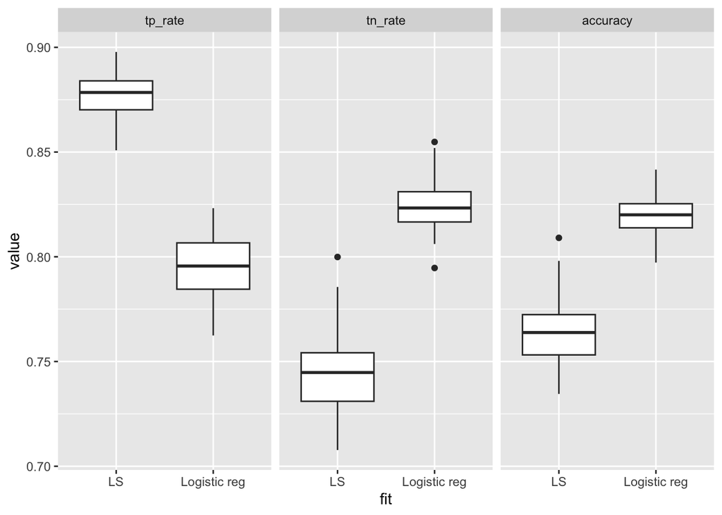

```r
shopping_data_perturbed_ls |>
  # select the relevant columns (and create a "fit" column)
  transmute(iter, tp_rate, tn_rate, accuracy, fit = "LS") |>
  # add the rows for the logistic regression fit
  rbind(transmute(shopping_data_perturbed_lr,
                  iter, tp_rate, tn_rate, accuracy, fit = "Logistic reg")) |>
  pivot_longer(c(tp_rate, tn_rate, accuracy),
               names_to = "measure", values_to = "value") |>
  # make sure that the fits and measures appear in the same order as in the book
  mutate(fit = fct_inorder(fit),
         measure = fct_inorder(measure)) |>
  ggplot() +
  geom_boxplot(aes(x = fit, y = value)) +
  facet_wrap(~measure)
```

Lastly, let’s look at the distributions of the coefficients themselves. To do that, we need to extract the coefficients from the perturbed LS fits. However, since the coefficients are not inherently on the same scale, we need to either standardize the coefficients themselves (e.g., using the bootstrap), or we need to standardize the features before we generate the LS fit. Since it is computationally easier to take the latter approach, the code below does exactly that:

```r
perturbed_data_coefs_ls <- shopping_data_perturbed |>
  rowwise() |>
  # create a standardized version of each perturbed dataset
  mutate(data_train_preprocessed_perturbed_std =
           list(mutate(data_train_preprocessed_perturbed,
                       across(where(is.numeric), ~(. - mean(.)) / sd(.))))) |>
  # fit a LS to each standardized perturbed training dataset
  mutate(ls = list(lm(parse_number(as.character(purchase)) ~ .,
                      data_train_preprocessed_perturbed_std))) |>
  # extract just the coefficients
  transmute(iter, coefs = list(enframe(ls$coefficients,
                                       value = "coefficient",
                                       name = "variable"))) |>
  # undo the list column structure
  unnest(coefs) |>
  filter(variable != "(Intercept)")

# compute the perturbed coefficients for logistic regression
perturbed_data_coefs_lr <- shopping_data_perturbed |>
  rowwise() |>
  # create a standardized version of each perturbed dataset
  mutate(data_train_preprocessed_perturbed_std =
           list(mutate(data_train_preprocessed_perturbed,
                       across(where(is.numeric), ~(. - mean(.)) / sd(.))))) |>
  # fit a LS to each standardized perturbed training dataset
  mutate(lr = list(glm(factor(purchase, levels = c(0, 1)) ~ .,
                       data_train_preprocessed_perturbed_std,
                       family = "binomial"))) |>
  # extract just the coefficients
  transmute(iter, coefs = list(enframe(lr$coefficients,
                                       value = "coefficient",
                                       name = "variable"))) |>
  # undo the list column structure
  unnest(coefs) |>
  filter(variable != "(Intercept)")
```

Next, we can use boxplots to visualize the distributions of the largest (in absolute value) coefficients for each fit (note that in the book, we arrange the LS plot in the same order as the logistic regression plot, but we haven’t done that here).

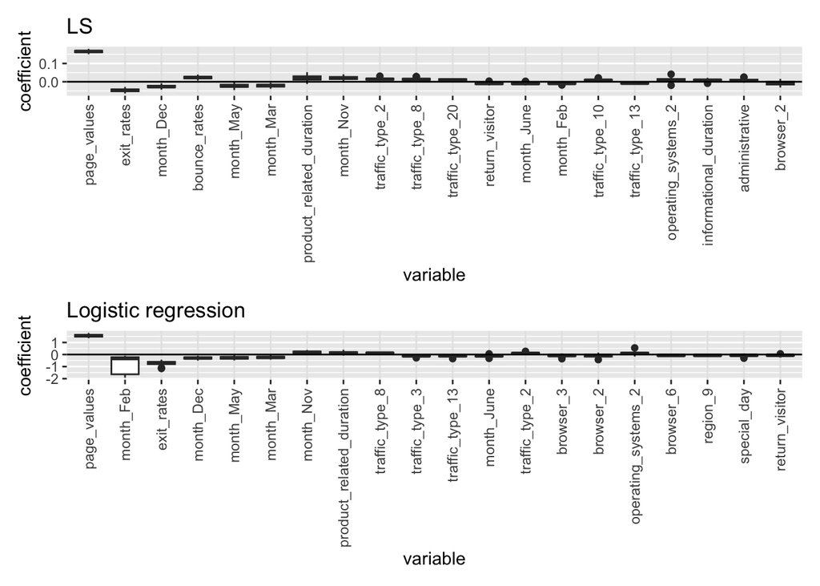

```r
# plot the logistic regression coefficients
gg_perturbed_data_coefs_lr <- perturbed_data_coefs_lr |>
  # arrange the coefficients in decreasing order of size
  group_by(variable) |>
  mutate(mean_coef = abs(mean(coefficient))) |>
  ungroup() |>
  arrange(desc(mean_coef)) |>
  # filter to just the top 20 features
  mutate(variable = fct_inorder(variable)) |>
  mutate(var_order = as.numeric(variable)) %>%
  filter(var_order <= 20)  %>%
  # plot the distributions of the coefficients
  ggplot() +
  geom_boxplot(aes(x = variable, y = coefficient)) +
  geom_hline(yintercept = 0) +
  theme(axis.text.x = element_text(angle = 90,
                                   hjust = 1,
                                   vjust = 0.5),
        panel.grid.major.x = element_line(color = "grey90")) +
  ggtitle("Logistic regression")



# plot the LS coefficients
gg_perturbed_data_coefs_ls <- perturbed_data_coefs_ls |>
  # arrange the coefficients in decreasing order of size
  group_by(variable) |>
  mutate(mean_coef = abs(mean(coefficient))) |>
  ungroup() |>
  arrange(desc(mean_coef)) |>
  # filter to just the top 20 features
  mutate(variable = fct_inorder(variable)) |>
  mutate(var_order = as.numeric(variable)) %>%
  filter(var_order <= 20)  %>%
  # plot the distributions of the coefficients
  ggplot() +
  geom_boxplot(aes(x = variable, y = coefficient)) +
  geom_hline(yintercept = 0) +
  theme(axis.text.x = element_text(angle = 90,
                                   hjust = 1,
                                   vjust = 0.5),
        panel.grid.major.x = element_line(color = "grey90")) +
  ggtitle("LS")


# arrange the plots on top of one another using patchwork syntax
gg_perturbed_data_coefs_ls / gg_perturbed_data_coefs_lr
```

### 4.3 Stability to cleaning/pre-processing judgment calls

The judgment calls that we will consider are:

1. Converting the numeric variables (such as `browser`, `region`, and `operating_system`) to categorical variables, or leaving them in a numeric format (just in case there is some meaningful order to the levels that we don’t know about).
2. Converting the categorical `month` variable to a numeric format (since there is a natural ordering to the months), or leaving it in a categorical format (which will be turned into one-hot encoded dummy variables during pre-processing).
3. Applying a log-transformation to the page visit and duration variables (because this makes the distributions look more symmetric, and may help improve predictive performance), or leaving them un-transformed.
4. Removing very extreme sessions (e.g., that visited over 400 product-related pages in a single session, or spent more than 12 hours on product-related pages in a single session) that may be bots, versus leaving them in the data. Note that we chose the thresholds that we use to define a potential “bot” session based on a visualization of the distributions of these variables.

Since each judgment call above has two options (TRUE or FALSE), so there are a total of $2^4 = 16$ different judgment call combinations that we will consider in this section.

The code below creates an object that contains a list column with each perturbed dataset.

First, we will create a grid of all of the judgment call options.

```r
numeric_to_cat = c(TRUE, FALSE)
month_numeric <- c(TRUE, FALSE)
log_page <- c(TRUE, FALSE)
remove_extreme <- c(TRUE, FALSE)
param_options <- expand_grid(numeric_to_cat,
                             month_numeric,
                             log_page,
                             remove_extreme)
```

Then we will create a version of the pre-processed dataset per each of the judgment call combination options. Note that unlike for the data perturbations (which were all based on the “default” pre-processed training dataset) where we could use the “default” validation dataset, we will need to explicitly create perturbed versions of the pre-processed validation data to match each perturbed version of the pre-processed training data.

```r
shopping_jc_perturbed <- param_options %>%
  rowwise() %>%
  # add training data list column
  mutate(data_train_preprocessed_perturbed =
           list(preprocessShoppingData(shopping_train,
                                    .numeric_to_cat = numeric_to_cat,
                                    .month_numeric = month_numeric,
                                    .log_page = log_page,
                                    .remove_extreme = remove_extreme)),
         .before = 1) %>%
  # create a version of the training data cat levels for matching val set to train set
  mutate(shopping_train_preprocessed_perturbed_nodummy =
           list(preprocessShoppingData(shopping_train,
                                    .numeric_to_cat = numeric_to_cat,
                                    .month_numeric = month_numeric,
                                    .log_page = log_page,
                                    .remove_extreme = remove_extreme,
                                    .dummy = FALSE))) %>%
  # extract the levels to use for ensuring the validation sets match the training set
  mutate(browser_levels =
           list(levels(shopping_train_preprocessed_perturbed_nodummy$browser)),
         operating_systems_levels =
           list(levels(shopping_train_preprocessed_perturbed_nodummy$operating_systems)),
         traffic_type_levels =
           list(levels(shopping_train_preprocessed_perturbed_nodummy$traffic_type))) %>%
  # add validation data list column
  mutate(data_val_preprocessed_perturbed =
           list(preprocessShoppingData(shopping_val,
                                    .numeric_to_cat = numeric_to_cat,
                                    .month_numeric = month_numeric,
                                    .log_page = log_page,
                                    .remove_extreme = remove_extreme,
                                    # make sure val columns match train columns
                                    .column_selection = colnames(data_train_preprocessed_perturbed),
                                    .operating_systems_levels = operating_systems_levels,
                                    .browser_levels = browser_levels,
                                    .traffic_type_levels = traffic_type_levels)),
         .after = "data_train_preprocessed_perturbed")

shopping_jc_perturbed
```

```
# A tibble: 16 × 10
# Rowwise:
   data_train_preprocessed…¹ data_val_preprocesse…² numeric_to_cat month_numeric
   <list>                    <list>                 <lgl>          <lgl>
 1 <tibble [7,361 × 46]>     <tibble [2,453 × 46]>  TRUE           TRUE
 2 <tibble [7,372 × 46]>     <tibble [2,456 × 46]>  TRUE           TRUE
 3 <tibble [7,361 × 46]>     <tibble [2,453 × 46]>  TRUE           TRUE
 4 <tibble [7,372 × 46]>     <tibble [2,456 × 46]>  TRUE           TRUE
 5 <tibble [7,361 × 54]>     <tibble [2,453 × 54]>  TRUE           FALSE
 6 <tibble [7,372 × 54]>     <tibble [2,456 × 54]>  TRUE           FALSE
 7 <tibble [7,361 × 54]>     <tibble [2,453 × 54]>  TRUE           FALSE
 8 <tibble [7,372 × 54]>     <tibble [2,456 × 54]>  TRUE           FALSE
 9 <tibble [7,361 × 18]>     <tibble [2,453 × 18]>  FALSE          TRUE
10 <tibble [7,372 × 18]>     <tibble [2,456 × 18]>  FALSE          TRUE
11 <tibble [7,361 × 18]>     <tibble [2,453 × 18]>  FALSE          TRUE
12 <tibble [7,372 × 18]>     <tibble [2,456 × 18]>  FALSE          TRUE
13 <tibble [7,361 × 26]>     <tibble [2,453 × 26]>  FALSE          FALSE
14 <tibble [7,372 × 26]>     <tibble [2,456 × 26]>  FALSE          FALSE
15 <tibble [7,361 × 26]>     <tibble [2,453 × 26]>  FALSE          FALSE
16 <tibble [7,372 × 26]>     <tibble [2,456 × 26]>  FALSE          FALSE
# ℹ abbreviated names: ¹data_train_preprocessed_perturbed,
#   ²data_val_preprocessed_perturbed
# ℹ 6 more variables: log_page <lgl>, remove_extreme <lgl>,
#   shopping_train_preprocessed_perturbed_nodummy <list>,
#   browser_levels <list>, operating_systems_levels <list>,
#   traffic_type_levels <list>
```

Then we can fit a LS and logistic regression fit to each perturbed dataset (and store these in list columns too). For each LS and logistic regression fit, we can then compute the validation set predictions and compute the relevant performance measures.

First, we will do this for the LS fits:

```r
shopping_jc_perturbed_ls <- shopping_jc_perturbed |>
  # create a single variable that dictates the judgment call combination
  unite("jc_options", numeric_to_cat:remove_extreme, remove = FALSE) |>
  rowwise() |>
  # fit a LS for each perturbed training dataset
  mutate(ls = list(lm(parse_number(as.character(purchase)) ~ .,
                      data_train_preprocessed_perturbed))) |>
  # create a list column of just the observed response vector
  mutate(true = list(factor(data_val_preprocessed_perturbed$purchase,
                            levels = c(1, 0)))) |>
  # compute a validation set prediction for each perturbed LS fit
  mutate(pred = list(predict(ls, data_val_preprocessed_perturbed))) |>
  # compute the performance metrics for each fit
  mutate(auc = roc_auc_vec(true, pred),
         tp_rate = sens_vec(true, factor(as.numeric(pred > 0.161), levels = c(1, 0))),
         tn_rate = spec_vec(true, factor(as.numeric(pred > 0.161), levels = c(1, 0))),
         accuracy = accuracy_vec(true, factor(as.numeric(pred > 0.161), levels = c(1, 0))),
         .after = "pred") %>%
  ungroup()
# Look at the object we created
print(shopping_jc_perturbed_ls, width = Inf)
```

```
# A tibble: 16 × 18
   data_train_preprocessed_perturbed data_val_preprocessed_perturbed
   <list>                            <list>
 1 <tibble [7,361 × 46]>             <tibble [2,453 × 46]>
 2 <tibble [7,372 × 46]>             <tibble [2,456 × 46]>
 3 <tibble [7,361 × 46]>             <tibble [2,453 × 46]>
 4 <tibble [7,372 × 46]>             <tibble [2,456 × 46]>
 5 <tibble [7,361 × 54]>             <tibble [2,453 × 54]>
 6 <tibble [7,372 × 54]>             <tibble [2,456 × 54]>
 7 <tibble [7,361 × 54]>             <tibble [2,453 × 54]>
 8 <tibble [7,372 × 54]>             <tibble [2,456 × 54]>
 9 <tibble [7,361 × 18]>             <tibble [2,453 × 18]>
10 <tibble [7,372 × 18]>             <tibble [2,456 × 18]>
11 <tibble [7,361 × 18]>             <tibble [2,453 × 18]>
12 <tibble [7,372 × 18]>             <tibble [2,456 × 18]>
```

[output cut: 76 more lines]

And then for the logistic regression fits:

```r
shopping_jc_perturbed_lr <- shopping_jc_perturbed |>
  # create a single variable that dictates the judgment call combination
  unite("jc_options", numeric_to_cat:remove_extreme, remove = FALSE) |>
  rowwise() |>
  # fit a logistic regression for each perturbed training dataset
  mutate(lr = list(glm(factor(purchase, levels = c(0, 1)) ~ .,
                       data_train_preprocessed_perturbed,
                       family = "binomial"))) |>
  # create a list column of just the observed response vector
  mutate(true = list(factor(data_val_preprocessed_perturbed$purchase,
                            levels = c(1, 0)))) |>
  # compute a validation set prediction for each perturbed LS fit
  mutate(pred = list(predict(lr, data_val_preprocessed_perturbed,
                             type = "response"))) |>
  # compute the performance metrics for each fit
  mutate(auc = roc_auc_vec(true, pred),
         tp_rate = sens_vec(true, factor(as.numeric(pred > 0.161), levels = c(1, 0))),
         tn_rate = spec_vec(true, factor(as.numeric(pred > 0.161), levels = c(1, 0))),
         accuracy = accuracy_vec(true, factor(as.numeric(pred > 0.161), levels = c(1, 0))),
         .after = "pred") %>%
  ungroup()
# Look at the object we created
print(shopping_jc_perturbed_lr, width = Inf)
```

```
# A tibble: 16 × 18
   data_train_preprocessed_perturbed data_val_preprocessed_perturbed
   <list>                            <list>
 1 <tibble [7,361 × 46]>             <tibble [2,453 × 46]>
 2 <tibble [7,372 × 46]>             <tibble [2,456 × 46]>
 3 <tibble [7,361 × 46]>             <tibble [2,453 × 46]>
 4 <tibble [7,372 × 46]>             <tibble [2,456 × 46]>
 5 <tibble [7,361 × 54]>             <tibble [2,453 × 54]>
 6 <tibble [7,372 × 54]>             <tibble [2,456 × 54]>
 7 <tibble [7,361 × 54]>             <tibble [2,453 × 54]>
 8 <tibble [7,372 × 54]>             <tibble [2,456 × 54]>
 9 <tibble [7,361 × 18]>             <tibble [2,453 × 18]>
10 <tibble [7,372 × 18]>             <tibble [2,456 × 18]>
11 <tibble [7,361 × 18]>             <tibble [2,453 × 18]>
12 <tibble [7,372 × 18]>             <tibble [2,456 × 18]>
```

[output cut: 76 more lines]

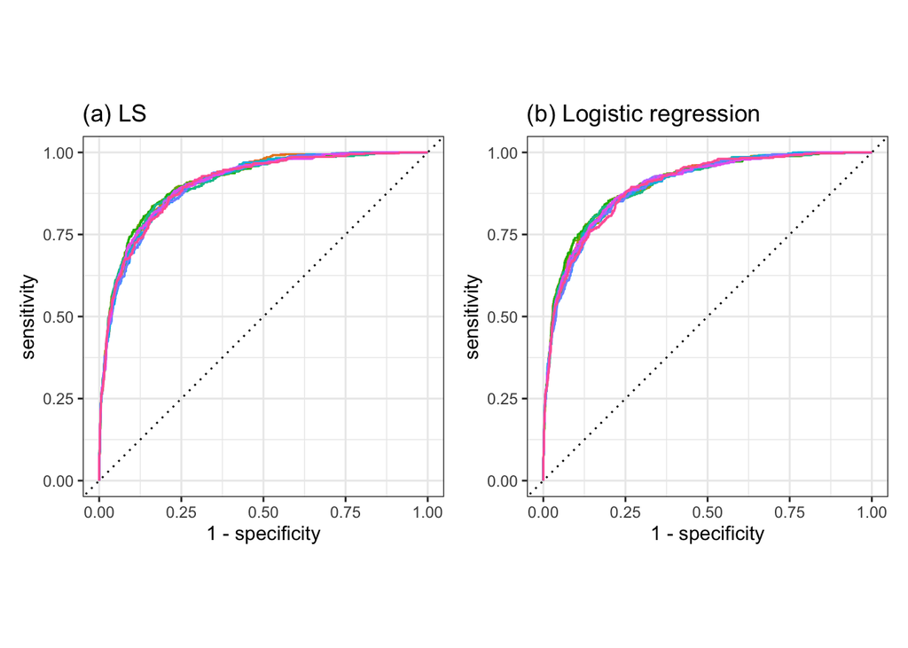

```r
gg_roc_ls_stab_jc <- shopping_jc_perturbed_ls %>%
  # select just the relevant columns
  select(jc_options, true, pred) %>%
  # unnest the predictions and true purchase response from the list columns
  unnest(c(true, pred)) %>%
  # compute the ROC curve for each perturbed set of predictions
  group_by(jc_options) %>%
  roc_curve(true, pred) %>%
  autoplot() +
  ggtitle("(a) LS") +
  theme(legend.position = "none")

gg_roc_lr_stab_jc <- shopping_jc_perturbed_lr %>%
  # select just the relevant columns
  select(jc_options, true, pred) %>%
  # unnest the predictions and true purchase response from the list columns
  unnest(c(true, pred)) %>%
  # compute the ROC curve for each perturbed set of predictions
  group_by(jc_options) %>%
  roc_curve(true, pred) %>%
  autoplot() +
  ggtitle("(b) Logistic regression") +
  theme(legend.position = "none")

gg_roc_ls_stab_jc + gg_roc_lr_stab_jc
```

Notice how the ROC curves seem very stable.

Next, let’s look at the distribution of the other performance measures using boxplots.

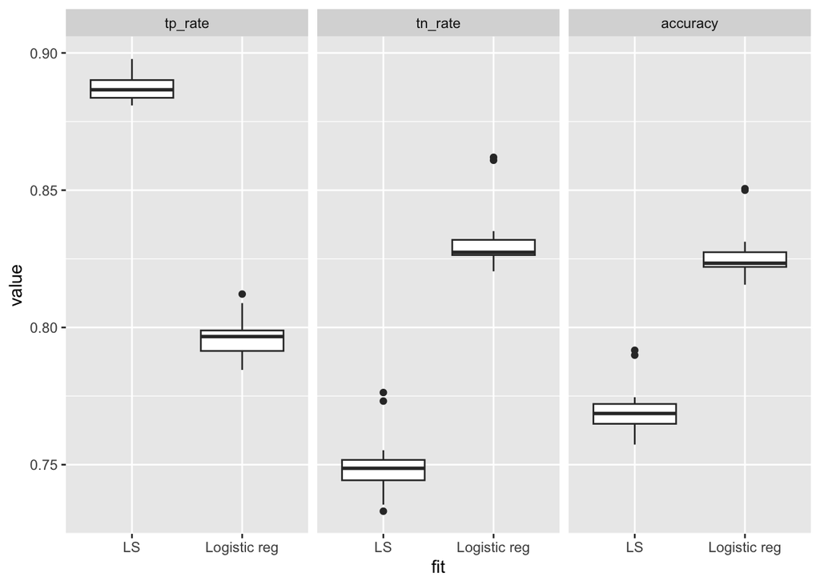

```r
shopping_jc_perturbed_ls |>
  # select the relevant columns (and create a "fit" column)
  transmute(jc_options, tp_rate, tn_rate, accuracy, fit = "LS") |>
  # add the rows for the logistic regression fit
  rbind(transmute(shopping_jc_perturbed_lr,
                  jc_options, tp_rate, tn_rate, accuracy, fit = "Logistic reg")) |>
  pivot_longer(c(tp_rate, tn_rate, accuracy),
               names_to = "measure", values_to = "value") |>
  # make sure that the fits and measures appear in the same order as in the book
  mutate(fit = fct_inorder(fit),
         measure = fct_inorder(measure)) |>
  ggplot() +
  geom_boxplot(aes(x = fit, y = value)) +
  facet_wrap(~measure)
```

We can also compare these performance measures across different judgment call options:

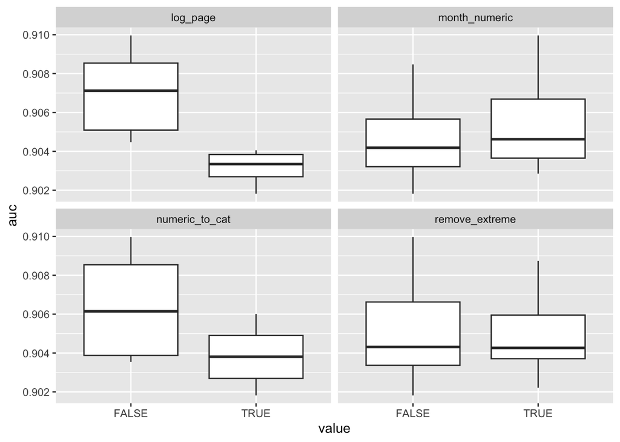

```r
# look at the distribution of AUC across different performance measures
shopping_jc_perturbed_ls |>
  arrange(desc(auc)) |>
  select(numeric_to_cat:remove_extreme, auc) |>
  pivot_longer(c('numeric_to_cat',
                 'month_numeric',
                 'log_page',
                 'remove_extreme')) |>
  ggplot() +
  geom_boxplot(aes(x = value, y = auc)) +
  facet_wrap(~name)
```

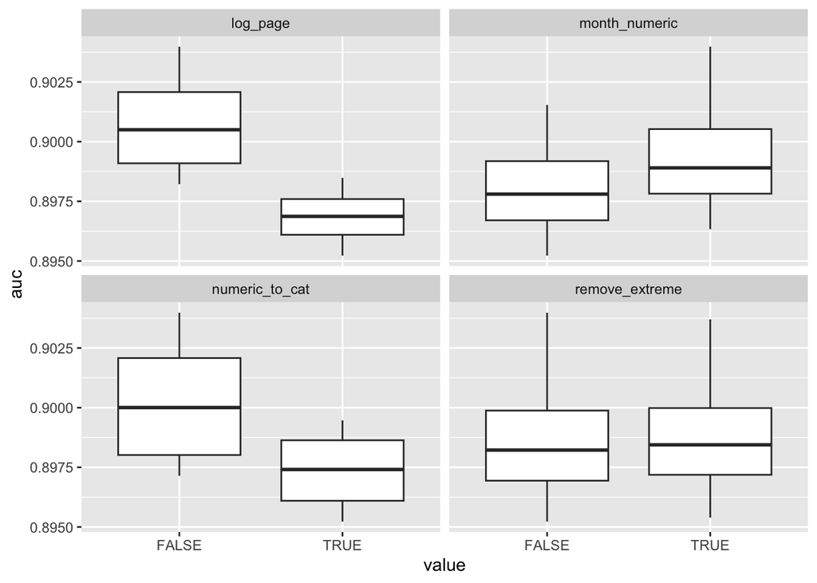

```r
# look at the distribution of AUC across different performance measures
shopping_jc_perturbed_lr |>
  arrange(desc(auc)) |>
  select(numeric_to_cat:remove_extreme, auc) |>
  pivot_longer(c('numeric_to_cat',
                 'month_numeric',
                 'log_page',
                 'remove_extreme')) |>
  ggplot() +
  geom_boxplot(aes(x = value, y = auc)) +
  facet_wrap(~name)
```

Lastly, let’s look at the distributions of the coefficients themselves. To do that, we need to extract the coefficients from the perturbed LS fits. However, since the coefficients are not inherently on the same scale, we need to either standardize the coefficients themselves (e.g., using the bootstrap), or we need to standardize the features before we generate the LS fit. Since it is computationally easier to take the latter approach, the code below does exactly that:

```r
perturbed_jc_coefs_ls <- shopping_jc_perturbed |>
  # create a single variable that dictates the judgment call combination
  unite("jc_options", numeric_to_cat:remove_extreme) |>
  rowwise() |>
  # create a standardized version of each perturbed dataset
  mutate(data_train_preprocessed_perturbed_std =
           list(mutate(data_train_preprocessed_perturbed,
                       across(where(is.numeric), ~(. - mean(.)) / sd(.))))) |>
  # fit a LS to each standardized perturbed training dataset
  mutate(ls = list(lm(parse_number(as.character(purchase)) ~ .,
                      data_train_preprocessed_perturbed_std))) |>
  # extract just the coefficients
  transmute(jc_options, coefs = list(enframe(ls$coefficients,
                                       value = "coefficient",
                                       name = "variable"))) |>
  # undo the list column structure
  unnest(coefs) |>
  filter(variable != "(Intercept)")

# compute the perturbed coefficients for logistic regression
perturbed_jc_coefs_lr <- shopping_jc_perturbed |>
  # create a single variable that dictates the judgment call combination
  unite("jc_options", numeric_to_cat:remove_extreme) |>
  rowwise() |>
  # create a standardized version of each perturbed dataset
  mutate(data_train_preprocessed_perturbed_std =
           list(mutate(data_train_preprocessed_perturbed,
                       across(where(is.numeric), ~(. - mean(.)) / sd(.))))) |>
  # fit a LS to each standardized perturbed training dataset
  mutate(lr = list(glm(factor(purchase, levels = c(0, 1)) ~ .,
                       data_train_preprocessed_perturbed_std,
                       family = "binomial"))) |>
  # extract just the coefficients
  transmute(jc_options, coefs = list(enframe(lr$coefficients,
                                       value = "coefficient",
                                       name = "variable"))) |>
  # undo the list column structure
  unnest(coefs) |>
  filter(variable != "(Intercept)")
```

Next, we can use boxplots to visualize the distributions of the largest (in absolute value) coefficients for each fit (note that in the book, we arrange the LS plot in the same order as the logistic regression plot, but we haven’t done that here).

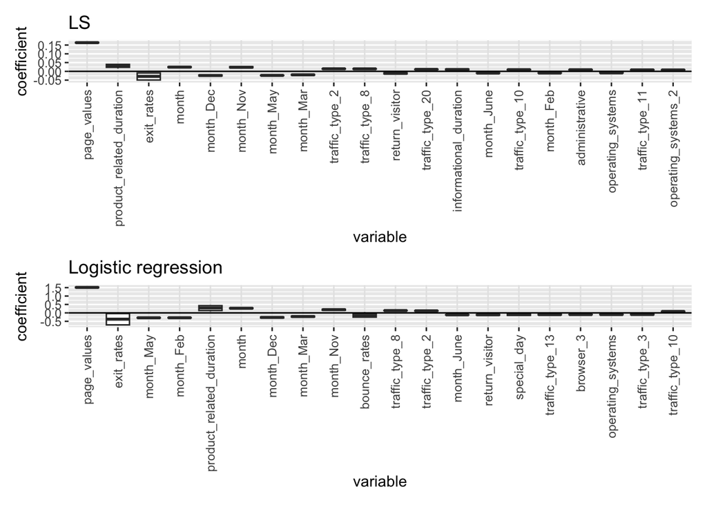

```r
# plot the logistic regression coefficients
gg_perturbed_jc_coefs_lr <- perturbed_jc_coefs_lr |>
  # arrange the coefficients in decreasing order of size
  group_by(variable) |>
  mutate(mean_coef = abs(mean(coefficient))) |>
  ungroup() |>
  arrange(desc(mean_coef)) |>
  # filter to just the top 20 features
  mutate(variable = fct_inorder(variable)) |>
  mutate(var_order = as.numeric(variable)) %>%
  filter(var_order <= 20)  %>%
  # plot the distributions of the coefficients
  ggplot() +
  geom_boxplot(aes(x = variable, y = coefficient)) +
  geom_hline(yintercept = 0) +
  theme(axis.text.x = element_text(angle = 90,
                                   hjust = 1,
                                   vjust = 0.5),
        panel.grid.major.x = element_line(color = "grey90")) +
  ggtitle("Logistic regression")



# plot the LS coefficients
gg_perturbed_jc_coefs_ls <- perturbed_jc_coefs_ls |>
  # arrange the coefficients in decreasing order of size
  group_by(variable) |>
  mutate(mean_coef = abs(mean(coefficient))) |>
  ungroup() |>
  arrange(desc(mean_coef)) |>
  # filter to just the top 20 features
  mutate(variable = fct_inorder(variable)) |>
  mutate(var_order = as.numeric(variable)) %>%
  filter(var_order <= 20)  %>%
  # plot the distributions of the coefficients
  ggplot() +
  geom_boxplot(aes(x = variable, y = coefficient)) +
  geom_hline(yintercept = 0) +
  theme(axis.text.x = element_text(angle = 90,
                                   hjust = 1,
                                   vjust = 0.5),
        panel.grid.major.x = element_line(color = "grey90")) +
  ggtitle("LS")


# arrange the plots on top of one another using patchwork syntax
gg_perturbed_jc_coefs_ls / gg_perturbed_jc_coefs_lr
```

When looking at the coefficients it seems as though the coefficient of exit rate is less stable to the judgment calls than the other variables.

## Footnotes

[^1]: Not that this is a good threshold to use here, but it suffices for this example. A better threshold would be the proportion of sessions that ended with a purchase in the training data, but the conclusion remains the same.